# 7 - Datenjournalismus, Hausaufgabe und Abschluss

Benedict Witzenberger  
18. April 2019

### Was wir jetzt noch vorhaben

Kleiner Ausblick auf Datenvisualisierung mit R

Ein bisschen was zum Datenjournalistenworkflow

Wir sprechen über das Kursprojekt

Und es gibt eine kleine Hausaufgabe (juchu!)

### Datenvisualisierung mit R

Dazu gibt es einen ganzen Blockkurs (Teil IV)

Deswegen nur eine kleine Einführung:

R kann in zahlreichen Formaten Grafiken ausgeben: PNG, JPEG, PDF, SVG, …

R kann praktisch alle Grafikformen darstellen, komplizierte Formen müssen händisch programmiert werden.

Es gibt zwei Hauptbibliotheken für Grafiken: Base und ggplot2

### ggplot2

Entwickelt seit 2005 von Hadley Wickham

basiert auf Leland Wilkinsons “Grammar of Graphics” - das heißt: Grafiken werden in Einzelteile zerlegt und dargestellt.

das heißt für uns: Wir können die Grafiken sehr einfach umkonfigurieren

eines der beliebtesten R-Packages

aktuelle Version 3.1.1

Der Einstieg ist relativ einfach, aber die Möglichkeiten muss man sich aufwendiger erschließen

### Base

Standard-Grafikbibliothek in R, vorinstalliert.

Geht sehr einfach und schnell

Reicht für kleine Analysen

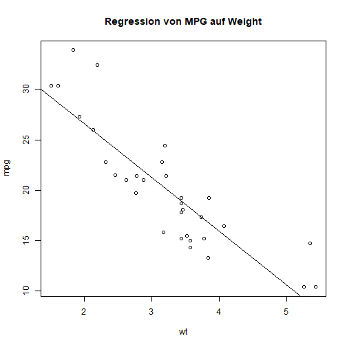

```r
attach(mtcars)
plot(wt, mpg)
abline(lm(mpg~wt))
title("Regression von MPG auf Weight")
```

### Scatterplot

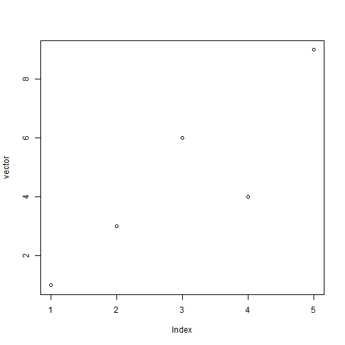

```r
vector <- c(1, 3, 6, 4, 9)

plot(vector)
```

Weitere Einstellungsmöglichkeiten in `plot()`:

`main =` Titel

`xlab/ylab =` X-Achsenbeschriftung

`pch =` Form der Punkte:

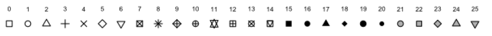

`col =` Farbe

`font =` Schriftart

`cex =` Schriftgrößen (in diversen Abstufungen, wie cex.main, cex.sub, cex.lab)

`frame =` TRUE/FALSE für Rahmen

### Liniendiagramm

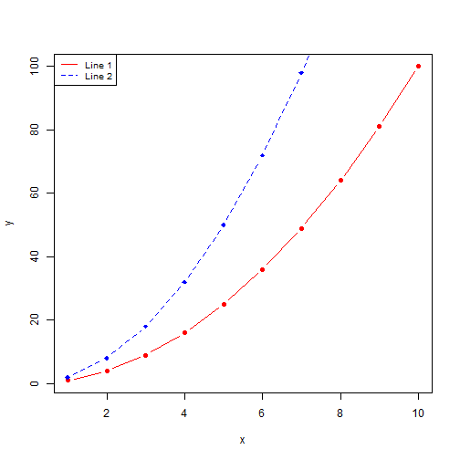

```r
x<-1:10; y1=x*x; y2=2*y1

plot(x, y1, type="b", pch=19, col="red", xlab="x", ylab="y")

lines(x, y2, pch=18, col="blue", type="b", lty=2)

legend("topleft", legend=c("Line 1", "Line 2"),
       col=c("red", "blue"), lty=1:2, cex=0.8)
```

Wichtig: `lines()` alleine zeichnet keinen Graph, vorher muss `plot()` aufgerufen werden.

`type =` welcher Plot-Typ gezeichnet werden soll (“p” für “points”, “l” für “lines”, “b” für “both”)

`lty =` Linientyp

`legend()` fügt eine Legende hinzu

### Säulendiagramm

Nutzen wir das Dataset VADeaths (Todesrate pro 1000 in Virginia in 1940, Altersgruppen ab 50 Jahren):

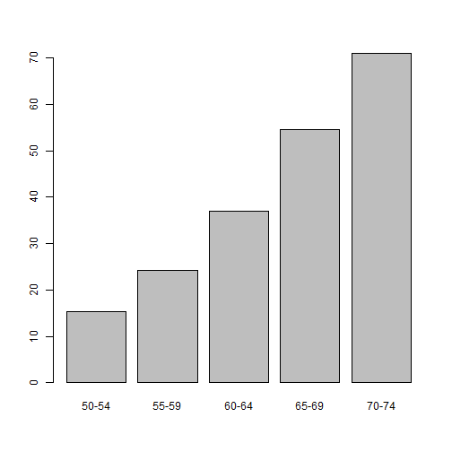

```r
x <- VADeaths[1:5, "Urban Male"]

barplot(x)
```

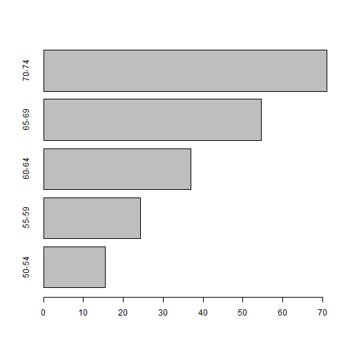

```r
barplot(x, horiz = TRUE)
```

`names.arg =` Namen der Gruppen ändern

`border =` Farbe der Ränder (einzeln, oder als Vektor)

`beside =` TRUE/FALSE für gruppierte Säulen/Balken

`legend = rownames(VADeaths)` würde das Diagramm stapeln.

### Histogramm

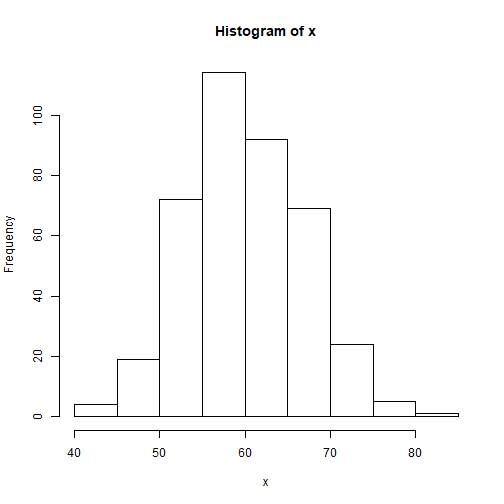

```r
x <- c(rnorm(200, mean=55, sd=5), rnorm(200, mean=65, sd=5))

hist(x)
```

### Abwandlung: Desityplot

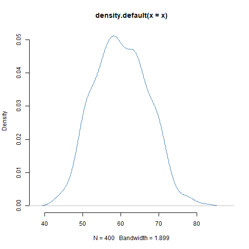

```r
dens <- density(x)
plot(dens, frame = FALSE, col = "steelblue")
```

`breaks =` legt die Zahl der Bruchpunkte fest (oder den Algorithmus, der sie berechnet - z.B. Strurges (default) Scott oder Freedman-Diaconis)

`polygon(dens, col = "steelblue")` würde den Density-Plot mit Farbe füllen

### Graph als Bild speichern

In RStudio:

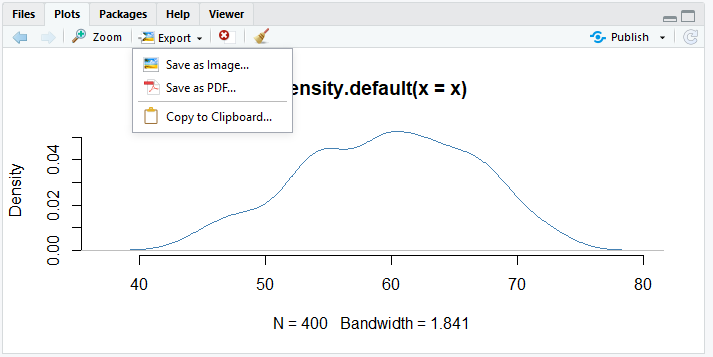

Im R-Code:

- Vor dem `plot()`: `jpeg()`, `png()`, `svg()` oder `pdf()` mit entsprechendem Dateinamen und (falls gewünscht) Größenangaben (`width`, `height`)
- `plot()` erstellen
- `dev.off()`

```
jpeg("grafik.jpg", width = 1024, height = 768, units = "px")
plot(x, y, main = "Das ist der Titel")
dev.off()
```

### Datenjournalismus: Zwei Herangehensweisen

### Von den Daten her

Wir haben Daten und suchen darin nach einer Geschichte:

- Minimum/Maximum
- Ausreißer
- NAs, wo keine sein sollten; Daten, wo keine sein sollten
- Durchschnitt
- Häufungen
- Wandel, Trends
- Muster aufzeigen

### Von der These her

Lassen sich Daten finden, die These bestätigen können?

- These operationalisieren
- Datenbanken durchsuchen
- Forscher kontaktieren
- eigene Variablen messen
- eigene Berechnungen durchführen
- <– auch die Fragen von links helfen

### Ist Datenjournalismus wirklich nötig?

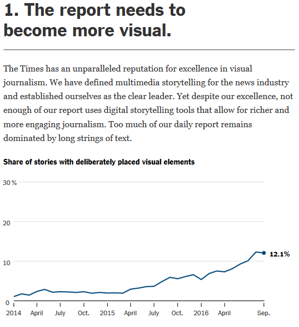

Quelle: [New York Times 2020 Report](https://www.nytimes.com/projects/2020-report/index.html)

### Was ist Datenjournalismus?

> “important, focused information that is useful to people’s lives and helps them understand the world” *Adrian Holovaty 2006*

Daten + Frage + Analytisches Vorgehen = Datenjournalismus

### Wer macht Datenjournalismus?

- Sozialwissenschaftler
- Entwickler
- Kartographen
- Statistiker
- Mathematiker
- bislang wenige “studierte” Datenjournalisten (aber es gibt inzwischen einige Studiengänge: Dortmund, Leipzig)

### Welche Skills braucht es?

- Data Literacy
- Programmieren/Coden (oder: Tools kennen?)
- Designen
- Schreiben
- Recherchieren
- Transparenz

### Wie funktioniert Datenjournalismus

Daten recherchieren

-> Daten bereinigen

-> Daten analysieren [Aufgabe der Datenjournalisten, nur manchmal mit Entwicklern]

-> Daten visualisieren [Designer und Entwickler]

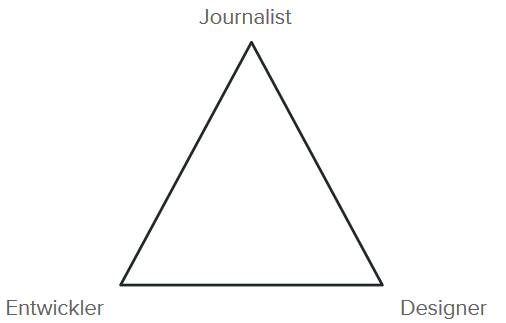

### Datenjournalismus bei der SZ

“Daten-Team” der Entwicklungsredaktion (neben Video, Podcast, Storytelling):

- 3 DatenjournalistInnen von SZ.de
- ein SZ.de-Datenvolontär
- 2 Datenjournalisten von der Zeitung
- 1-2 Entwickler
- 1 Designer

**Technik**: R, Phyton, QGis, Spark, Javascript, SQL, HTML, CSS, Google Docs, Adobe Illustrator

**Projektdauer**: kurz-, mittel- und langfristige Projekte. Tendenz: mittel- und langfristig

**Ziel**: Visuellen Journalismus bei der SZ fördern, ansprechbar sein für “programmierte Recherche”, Knowhow im Bereich AI/KI und Datenschutz

### Zwei Beispiele für SZ-Datenstücke

[Ein Jahr Trump](http://sz.de/1.3826251)

[Liga der Langeweile](http://sz.de/1.3836500)

### Wo kommen die Daten her?

Früher vor allem bestehende Datenbanken:

- DeStatis
- data.un.org
- www.who.int/gho/database/en/

Heute eher:

- Twitter
- OpenStreetMap

Theoretisch: Alles, was scrapebar ist

### Was ändert sich?

- Open Source und Open Data wird immer mehr (in Deutschland nur sehr zurückhaltend)
- Informationsfreiheitsgesetze in Deutschland (und den meisten Ländern, immer noch drei Bundesländer ohne entsprechende Gesetze: Bayern, Niedersachsen, Sachsen)
- sehr gut vernetzte Datenjournalistenszene
- Programmieren lernen wird immer einfacher (Codecademy etc.)
- viele kostenlose oder billige Tools (Datawrapper, CartoDB, QGIS)

### Kritik: Stagnation im Datenjournalismus

> “Allerdings meine ich, eine Stagnation zu beobachten: Lebte das Genre in den ersten Jahren vom Reiz des Neuen, das Dank aufsehenserregender Visualisierungen hervorstach, sind die Formate nun weitgehend ausgereizt. […] Doch der Drang zum Leuchtturm-Projekt (oder Liebhaber-Projekt einzelner Redakteure) herrscht weiter vor. Ich persönlich finde das mittlerweile recht ermüdend, weil eben keine Weiterentwicklung zu erkennen ist: Weder thematisch noch konzeptionell. Im Gegenteil: Die Themensetzung wirkt oft wahllos oder gar willkürlich.”

> *Lorenz Matzat Ende 2018 auf seinem [Blog](https://www.datenjournalist.de/10-jahre-datenjournalismus-gemischte-gefuehle/)*

Antwort der SZ-Daten-Teamleiterin:

[figure not shown]

[Quelle zum Tweet](https://twitter.com/Remrow/status/1075692284195295233)

Mehr dazu: [Gespräch in “Was mit Medien” (Dlf Nova)](https://www.deutschlandfunknova.de/beitrag/datenjournalismus-wenn-big-data-fuer-schlagzeilen-sorgt)

### Wie geht's jetzt weiter?

**Vorschlag**: Wir entwickeln alleine oder in Kleingruppen datenjournalistische Projekte, die am Ende des R-Bootcamps fertig sein sollen.

### Fragen:

Was passt zu euch / zu eurer Redaktion?

Habt ihr Ideen oder Thesen?

Wo könntet ihr anfangen zu suchen?

### Next Steps:

Daten organisieren/recherchieren

Wir sprechen uns am *20. Mai um 20.15 Uhr* per Videocall, bis dahin sollte die These stehen.

Bei Fragen könnt ihr jederzeit in Slack (ddj19) schreiben, oder mir eine Mail schicken: b.witzenberger@gmail.com

### Hausaufgabe

Im Github habe ich eine Aufgabe vorbereitet, die euer Wissen aus diesem Seminar testen soll.

### Abschluss Block 1

Abschlussrunde:

- Was ist bei euch besonders hängen geblieben?
- Was hättet ihr gerne mehr gemacht? / was weniger?
- Habt ihr das Gefühl, ihr habt alles verstanden?